# GLMs for Car Insurance Pricing: Initial Modeling

Mick Cooney mickcooney@gmail.com

13 July 2016

This document is part of a series investigating the use of generalised linear models to price car insurance. This document focuses on the production of some simple GLM models for both a Poisson and a Gamma process to assess both the frequency and the size of claims. We will discuss different ways to model claims and then combine these to produce a price for the premium.

# 1 Load Data

```r
policy_dt      <- read_rds("data/policy_dt.rds")
claim_dt       <- read_rds("data/claim_dt.rds")
policyclaim_dt <- read_rds("data/policyclaim_dt.rds")

setDT(policy_dt)
setDT(claim_dt)
setDT(policyclaim_dt)

glimpse(policyclaim_dt)
```

```
## Observations: 413,169
## Variables: 17
## $ policy_id      <fct> 1, 2, 3, 4, 5, 6, 7, 8, 9, 10, 11, 12, 13, 14, 15, 16, 17, 18,...
## $ claim_count    <int> 0, 0, 0, 0, 0, 0, 0, 0, 0, 0, 0, 0, 0, 0, 0, 0, 0, 0, 0, 0, 0,...
## $ exposure       <dbl> 0.09, 0.84, 0.52, 0.45, 0.15, 0.75, 0.81, 0.05, 0.76, 0.34, 0....
## $ power          <fct> g, g, f, f, g, g, d, d, d, i, f, f, e, e, e, e, e, e, i, i, h,...
## $ car_age        <int> 0, 0, 2, 2, 0, 0, 1, 0, 9, 0, 2, 2, 0, 0, 0, 0, 0, 0, 0, 0, 0,...
## $ driver_age     <int> 46, 46, 38, 38, 41, 41, 27, 27, 23, 44, 32, 32, 33, 33, 33, 54...
## $ brand          <fct> Japanese (except Nissan) or Korean, Japanese (except Nissan) o...
## $ fuel           <fct> Diesel, Diesel, Regular, Regular, Diesel, Diesel, Regular, Reg...
## $ region         <fct> Aquitaine, Aquitaine, Nord-Pas-de-Calais, Nord-Pas-de-Calais, ...
## $ density        <int> 76, 76, 3003, 3003, 60, 60, 695, 695, 7887, 27000, 23, 23, 174...
## $ total_claims   <dbl> 0, 0, 0, 0, 0, 0, 0, 0, 0, 0, 0, 0, 0, 0, 0, 0, 0, 0, 0, 0, 0,...
## $ cat_driver_age <chr> "(42,74]", "(42,74]", "(26,42]", "(26,42]", "(26,42]", "(26,42...
## $ cat_car_age    <chr> "[0,1]", "[0,1]", "(1,4]", "(1,4]", "[0,1]", "[0,1]", "[0,1]",...
## $ cat_density    <chr> "(40,200]", "(40,200]", "(500,4.5e+03]", "(500,4.5e+03]", "(40...
## $ agg_power      <chr> "4", "4", "3", "3", "4", "4", "1", "1", "1", "other", "3", "3"...
## $ agg_power_2    <chr> "4", "4", "3", "3", "4", "4", "1", "1", "1", "6", "3", "3", "2...
## $ agg_region     <int> 1, 1, 8, 8, 9, 9, 1, 1, 8, 6, 4, 4, 6, 6, 6, 8, 6, 6, 6, 6, 6,...
```

We convert the tables to `data.table` as this makes some of the later work a little faster as we can add columns to tables in-place efficiently.

For the moment, we are not really building any predictive models, so we are not doing the standard train/test split. We will approach this later when building models and using them to produce predictions.

# 2 Modelling Claims

To model the claims in the book of policy we split the claim modelling into two parts: we first try to model the frequency of claims for each policy, and then we try to assess the size of the claims. By multiplying these two together we get a sense of the cost of each policy.

Due to the highly random nature of claim costs, we expect it to be much harder to predict the claim size from the covariates. Most of the predictive power is likely to be in modelling the claims frequency.

We will need to do some further data exploration as part of this work, but rather than trying to understand the data, the purpose of this is model-building: we want to get a sense for how the outputs of interest vary across the different parameters and see if we can improve the models by using this.

## 2.1 Modelling the Claim Frequency

The standard method for modelling the frequency of an event is the *Poisson* process - we assume events occur randomly but distributed as a Poisson process, and then our predictions affect the parameter of this process: the *rate* parameter $\lambda$.

The $\lambda$ parameter in a Poisson process is the frequency of the occurrence for a given unit of time. The most natural unit of time for us is a year - the standard length of exposure for a policy - and so if $\lambda = 2$ that means we expect an event to occur twice a year on average.

Before we model anything with the data, we first take a look at the overall rate of claims on the book as a whole. This allows us to anchor our expectations for parameters, not to mention that it serves as a simple ‘sanity’ check for the data.

```r
policyclaim_dt %>%
    summarise(claim_rate = sum(claim_count) / sum(exposure))
```

```
##    claim_rate
## 1: 0.06979859
```

The overall claim rate for the book as a whole is just under 0.07 claims per policy per year.

Breaking this down a little further, we can do a similar calculation by different combinations of categorical variables, such as by region or by age category.

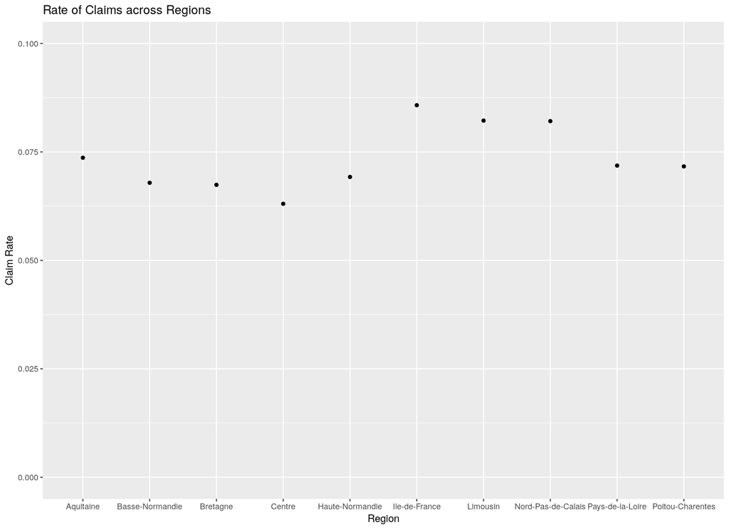

```r
claimrate_region_dt <- policyclaim_dt %>%
    group_by(region) %>%
    summarise(claimrate = sum(claim_count) / sum(exposure))

ggplot(claimrate_region_dt) +
    geom_point(aes(x = region, y = claimrate)) +
    expand_limits(y = c(0, 0.1)) +
    xlab("Region") +
    ylab("Claim Rate") +
    ggtitle("Rate of Claims across Regions")
```

For the purposes of looking at the effect of age on claim rates, we will look at the categorised data in preference to using it as a continuous variable. We may use either in the modelling, but for visualisation of this effect, we use the categories.

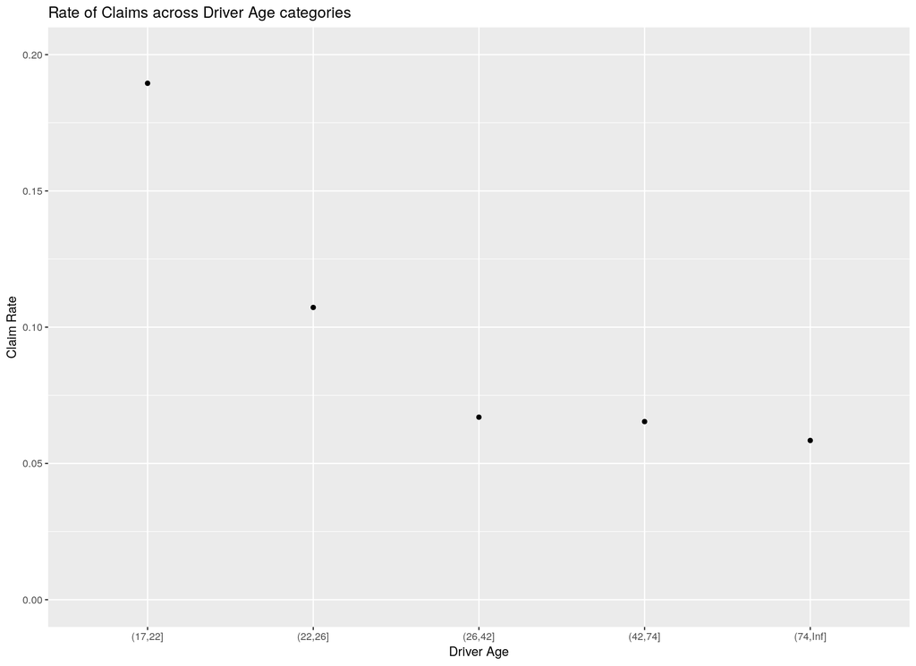

```r
claimrate_driverage_dt <- policyclaim_dt %>%
    group_by(cat_driver_age) %>%
    summarise(claimrate = sum(claim_count) / sum(exposure))

ggplot(claimrate_driverage_dt) +
    geom_point(aes(x = cat_driver_age, y = claimrate)) +
    expand_limits(y = c(0, 0.2)) +
    xlab("Driver Age") +
    ylab("Claim Rate") +
    ggtitle("Rate of Claims across Driver Age categories")
```

There is a strong pattern here: younger drivers crash more - not an unexpected result. We will try the same thing but with the actual value, just to get a sense of the relationship between age and claim frequency.

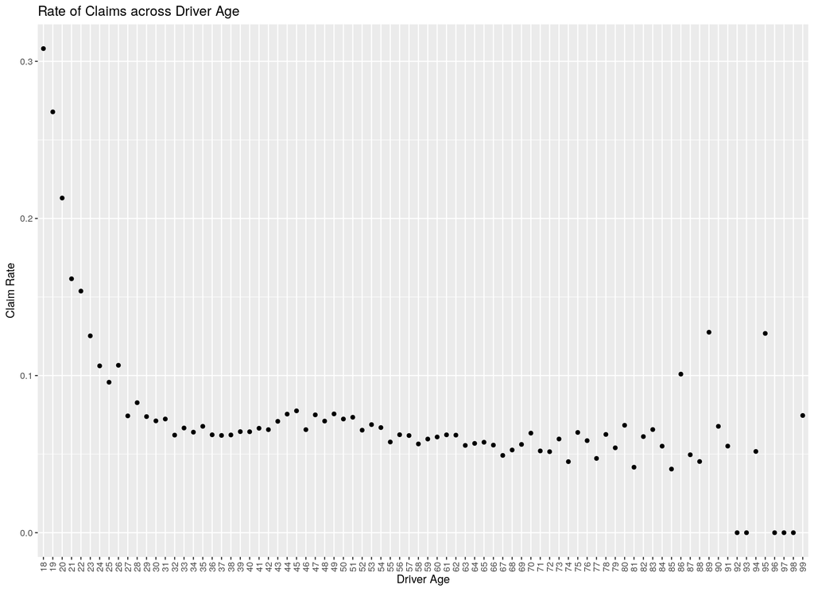

```r
claimrate_driverage_dt <- policyclaim_dt %>%
    mutate(group_age = as.character(driver_age)) %>%
    group_by(group_age) %>%
    summarise(claimrate = sum(claim_count) / sum(exposure))

ggplot(claimrate_driverage_dt) +
    geom_point(aes(x = group_age, y = claimrate)) +
    expand_limits(y = 0) +
    xlab("Driver Age") +
    ylab("Claim Rate") +
    ggtitle("Rate of Claims across Driver Age") +
    theme(axis.text.x = element_text(angle = 90, vjust = 0.5))
```

Treating ages a more continuous variable for grouping does show a nonlinear form, but for the higher age drivers there is so little data that we will stick with the categories we have for now and see where that leads us.

### 2.1.1 Poisson Regression

We turn our attention to building a first model for this: we will construct a GLM for the claim_count and use a Poisson link function to estimate our regression coefficients. This means we are regressing on the rate parameter of the Poisson function: our estimates can be interpreted as directly affected the rate of claims expected.

Before we begin, we do need to deal with the `exposure` variable: not all policies were in force for 1 year and our model needs to account for this. Strangely, we have policies in the dataset that had exposure for longer than a year also - we may end up excluding them later.

To understand this, we will go back to the underlying mathematics of this process.

Suppose we have $Y_i$, the number of claims from policy $i$ in a year. Assuming the underlying process is Poisson-distributed, this means that in units of a year we have

$$Y_i \sim \mathcal{P}(N_i)$$

where $N_i$ is the underlying rate of claims for policy $i$.

If policy $i$ is only in force for a fraction of the year, $E_i$, then $N_i$ is unobserveable: we can only observe $Y_i$ during the period of time $E_i$.

Thus, we have

$$Y_i \sim \mathcal{P}(\lambda_i \, E_i).$$

For Poisson regression we use a logarithm link function so that

$$\lambda_i = \exp{(X_i \beta)}$$

and

$$Y_i \sim \mathcal{P}(e^{X_i \beta + \log E_i})$$
.

For regression purposes, $\log E_i$ is an offset to RHS of the equation, and we use `offset()` in the formula to account for this.

### 2.1.2 A Simple Claim-rate Model

Before we start modeling the rate of claims “in anger”, we first get a sense for how this GLM works - modelling incident rates via a Poisson process. To that end, we will start with a very simple model and estimate the claim rate using only the type of fuel the car uses:

```r
model_fuel <- glm(claim_count ~ 0 + fuel + offset(log(exposure))
             ,family = poisson
             ,data = policyclaim_dt)

summary(model_fuel)
```

```
##
## Call:
## glm(formula = claim_count ~ 0 + fuel + offset(log(exposure)),
##     family = poisson, data = policyclaim_dt)
##
## Deviance Residuals:
##     Min       1Q   Median       3Q      Max
## -0.5092  -0.3610  -0.2653  -0.1488   6.5858
##
## Coefficients:
##             Estimate Std. Error z value Pr(>|z|)
## fuelDiesel  -2.59462    0.01088  -238.5   <2e-16 ***
## fuelRegular -2.73101    0.01137  -240.2   <2e-16 ***
## ---
## Signif. codes:  0 '***' 0.001 '**' 0.01 '*' 0.05 '.' 0.1 ' ' 1
##
## (Dispersion parameter for poisson family taken to be 1)
##
##     Null deviance: 450747  on 413169  degrees of freedom
## Residual deviance: 105537  on 413167  degrees of freedom
## AIC: 136799
##
## Number of Fisher Scoring iterations: 6
```

We now try to understand the meaning of this output.

We have added the $0$ to the formula to prevent the ‘Diesel’ level for `fuel` to be added to the intercept - we want two seperate values shown in the output.

The outputs are on the log scale, if we want to see their ‘natural’ values, i.e. the impact they have on the incidence rate, we need to exponentiate them.

```r
exp(coef(model_fuel))
```

```
##  fuelDiesel fuelRegular
##  0.07467412  0.06515364
```

According to this model, Diesel cars have claims at a rate of 0.0747 per year, whereas Regular fuel cars incur claims at a rate of 0.0652.

As a quick sanity check, we create some sample data and predict the output. If the data is for a year’s exposure with both a Diesel and Regular car, we expect to get similar answers as above:

```r
test_dt <- data.table(fuel     = c("Diesel", "Regular")
                     ,exposure = 1)

predict(model_fuel, newdata = test_dt, type = 'response')
```

```
##          1          2
## 0.07467412 0.06515364
```

We see that the predicted claim rates are the same as the coefficients of the model, matching what we would expect.

How does this compare to the observed claim rate observed by splitting across fuel type?

```r
policyclaim_dt %>%
    group_by(fuel) %>%
    summarise(claim_rate = sum(claim_count) / sum(exposure))
```

```
## Source: local data table [2 x 2]
##
## # A tibble: 2 x 2
##   fuel    claim_rate
##   <fct>        <dbl>
## 1 Diesel      0.0747
## 2 Regular     0.0652
```

We recover the same claim rates by fuel using all the above approaches. This makes sense, as we are doing the same thing in different ways, so it is good that we get the same answer each time!

### 2.1.3 Building the GLM

We start with a simple GLM with a small number of covariates (using some of our new engineered features):

```r
model1 <- glm(claim_count ~ cat_driver_age + density + agg_region +
                            offset(log(exposure))
             ,family = poisson
             ,data = policyclaim_dt)

summary(model1)
```

```
##
## Call:
## glm(formula = claim_count ~ cat_driver_age + density + agg_region +
##     offset(log(exposure)), family = poisson, data = policyclaim_dt)
##
## Deviance Residuals:
##     Min       1Q   Median       3Q      Max
## -0.7981  -0.3524  -0.2647  -0.1498   6.5293
##
## Coefficients:
##                          Estimate Std. Error z value Pr(>|z|)
## (Intercept)            -1.762e+00  3.753e-02 -46.939  < 2e-16 ***
## cat_driver_age(22,26]  -5.874e-01  4.604e-02 -12.758  < 2e-16 ***
## cat_driver_age(26,42]  -1.061e+00  3.631e-02 -29.228  < 2e-16 ***
## cat_driver_age(42,74]  -1.080e+00  3.545e-02 -30.460  < 2e-16 ***
## cat_driver_age(74,Inf] -1.182e+00  5.180e-02 -22.814  < 2e-16 ***
## density                 2.057e-05  1.480e-06  13.896  < 2e-16 ***
## agg_region              1.541e-02  3.371e-03   4.573 4.82e-06 ***
## ---
## Signif. codes:  0 '***' 0.001 '**' 0.01 '*' 0.05 '.' 0.1 ' ' 1
##
## (Dispersion parameter for poisson family taken to be 1)
##
##     Null deviance: 105613  on 413168  degrees of freedom
## Residual deviance: 104527  on 413162  degrees of freedom
## AIC: 135798
##
## Number of Fisher Scoring iterations: 6
```

Not that since we have a number of categorical variables, the first level of each variable is subsumed by the intercept.

This explains why all the `cat_driver_age` levels in the summary are negative. Younger drivers have higher claim rates and so being in a different age category tends to reduce the rate of claims made.

The above model has a single continuous variable: `density` and it is quite possible that assuming a linear relationship between this and the claim rate is flawed, so we will remove it and refit the model to see the effect.

```r
model2 <- glm(claim_count ~ cat_driver_age + agg_region +
                            offset(log(exposure))
             ,family = poisson
             ,data = policyclaim_dt)

summary(model2)
```

```
##
## Call:
## glm(formula = claim_count ~ cat_driver_age + agg_region + offset(log(exposure)),
##     family = poisson, data = policyclaim_dt)
##
## Deviance Residuals:
##     Min       1Q   Median       3Q      Max
## -0.6484  -0.3564  -0.2637  -0.1492   6.5332
##
## Coefficients:
##                         Estimate Std. Error z value Pr(>|z|)
## (Intercept)            -1.764189   0.037463 -47.091  < 2e-16 ***
## cat_driver_age(22,26]  -0.571005   0.046019 -12.408  < 2e-16 ***
## cat_driver_age(26,42]  -1.044151   0.036283 -28.778  < 2e-16 ***
## cat_driver_age(42,74]  -1.063641   0.035421 -30.029  < 2e-16 ***
## cat_driver_age(74,Inf] -1.169799   0.051785 -22.589  < 2e-16 ***
## agg_region              0.020466   0.003303   6.196  5.8e-10 ***
## ---
## Signif. codes:  0 '***' 0.001 '**' 0.01 '*' 0.05 '.' 0.1 ' ' 1
##
## (Dispersion parameter for poisson family taken to be 1)
##
##     Null deviance: 105613  on 413168  degrees of freedom
## Residual deviance: 104696  on 413163  degrees of freedom
## AIC: 135965
##
## Number of Fisher Scoring iterations: 6
```

This model does not fit as well - there was information in `density` that is not captured by `region`.

#### 2.1.3.1 Adding Vehicle Details

We also need to take into account the type of vehicle being insured. It seems sensible that different car types will have different effects on the likelihood of a claim. The dataset has a number of variables related to the vehicle:

- `car_age`
- `power`
- `brand`
- `fuel`

We will try adding all the variables (using our modified versions where appropriate):

```r
model3 <- glm(claim_count ~ cat_driver_age + agg_region +
                            cat_car_age + agg_power_2 + brand + fuel +
                            offset(log(exposure))
             ,family = poisson
             ,data = policyclaim_dt)

summary(model3)
```

```
##
## Call:
## glm(formula = claim_count ~ cat_driver_age + agg_region + cat_car_age +
##     agg_power_2 + brand + fuel + offset(log(exposure)), family = poisson,
##     data = policyclaim_dt)
##
## Deviance Residuals:
##     Min       1Q   Median       3Q      Max
## -0.7221  -0.3458  -0.2637  -0.1485   6.6430
##
## Coefficients:
##                                          Estimate Std. Error z value Pr(>|z|)
## (Intercept)                             -1.660083   0.059160 -28.061  < 2e-16 ***
## cat_driver_age(22,26]                   -0.598388   0.046118 -12.975  < 2e-16 ***
## cat_driver_age(26,42]                   -1.084671   0.036569 -29.661  < 2e-16 ***
## cat_driver_age(42,74]                   -1.091175   0.035795 -30.484  < 2e-16 ***
## cat_driver_age(74,Inf]                  -1.133461   0.052044 -21.779  < 2e-16 ***
## agg_region                               0.021226   0.003313   6.407 1.49e-10 ***
## cat_car_age(15,Inf]                     -0.297804   0.034845  -8.546  < 2e-16 ***
## cat_car_age(4,15]                       -0.024809   0.020624  -1.203 0.229015
## cat_car_age[0,1]                         0.022807   0.029077   0.784 0.432825
## agg_power_22                             0.082781   0.027969   2.960 0.003079 **
## agg_power_23                             0.095856   0.027396   3.499 0.000467 ***
## agg_power_24                             0.075072   0.027243   2.756 0.005858 **
## agg_power_25                             0.133326   0.038882   3.429 0.000606 ***
## agg_power_26                             0.227382   0.043080   5.278 1.31e-07 ***
## agg_power_27                             0.210492   0.043905   4.794 1.63e-06 ***
## agg_power_2other                         0.259384   0.044460   5.834 5.41e-09 ***
## brandJapanese (except Nissan) or Korean -0.158233   0.045127  -3.506 0.000454 ***
## brandMercedes, Chrysler or BMW          -0.002975   0.053042  -0.056 0.955279
## brandOpel, General Motors or Ford        0.041987   0.044814   0.937 0.348808
## brandother                              -0.049345   0.062258  -0.793 0.428017
## brandRenault, Nissan or Citroen         -0.110285   0.039162  -2.816 0.004860 **
## brandVolkswagen, Audi, Skoda or Seat     0.012308   0.045979   0.268 0.788944
## fuelRegular                             -0.115506   0.016977  -6.804 1.02e-11 ***
## ---
## Signif. codes:  0 '***' 0.001 '**' 0.01 '*' 0.05 '.' 0.1 ' ' 1
##
## (Dispersion parameter for poisson family taken to be 1)
##
##     Null deviance: 105613  on 413168  degrees of freedom
## Residual deviance: 104383  on 413146  degrees of freedom
## AIC: 135686
##
## Number of Fisher Scoring iterations: 6
```

The AIC for this model is smaller, matching our intuition that vehicle data has a strong effect on the rate of claims for a policy.

Our current aim is merely to get a feel for the models, so we will not pay too much attention to model assessment or validation. For starters, we have done little pruning of the data and have no created any sort of holdout set, and such a process could easily change our inferences!

Instead, we leave it there and instead turn our attention to modelling the size of the claims.

## 2.2 Modelling Claim Size

We turn our attention to modelling the size of the claim, given that a claim has occurred. We use the individual claim data for this, but will use variables from the policy table also. We are not modelling claims above EUR 25,000 so we exclude these data now.

```r
claimdata_dt <- policyclaim_dt %>%
    select(-c(claim_count)) %>%
    inner_join(claim_dt, by = 'policy_id') %>%
    filter(claim_amount < 25000)

print(claimdata_dt)
```

```
## Source: local data table [16,068 x 17]
##
## # A tibble: 16,068 x 17
##    policy_id exposure power car_age driver_age brand fuel  region density total_claims
##    <fct>        <dbl> <fct>   <int>      <int> <fct> <fct> <fct>    <int>        <dbl>
##  1 33            0.75 g           1         61 Japa… Regu… Ile-d…   27000          302
##  2 41            0.14 l           5         50 Japa… Dies… Basse…      56         2001
##  3 92            0.14 d           0         36 Japa… Regu… Ile-d…    4792         1449
##  4 96            0.62 j           0         51 Japa… Regu… Ile-d…   27000        10870
##  5 96            0.62 j           0         51 Japa… Regu… Ile-d…   27000        10870
##  6 142           0.75 e           0         34 Japa… Regu… Nord-…    1565         1390
##  7 182           0.68 d          10         24 Rena… Regu… Ile-d…    3064         1418
##  8 377           0.5  i           0         35 Japa… Regu… Ile-d…    1139          747
##  9 378           0.73 f           0         74 Japa… Regu… Ile-d…    3132         3332
## 10 401           0.65 f           8         49 Rena… Regu… Ile-d…    9082         2956
## # ... with 16,058 more rows, and 7 more variables: cat_driver_age <chr>,
## #   cat_car_age <chr>, cat_density <chr>, agg_power <chr>, agg_power_2 <chr>,
## #   agg_region <int>, claim_amount <int>
```

```r
glimpse(claimdata_dt)
```

```
## Observations: 16,068
## Variables: 17
## $ policy_id      <fct> 33, 41, 92, 96, 96, 142, 182, 377, 378, 401, 436, 438, 467, 46...
## $ exposure       <dbl> 0.75, 0.14, 0.14, 0.62, 0.62, 0.75, 0.68, 0.50, 0.73, 0.65, 0....
## $ power          <fct> g, l, d, j, j, e, d, i, f, f, i, j, i, i, e, e, e, g, g, g, l,...
## $ car_age        <int> 1, 5, 0, 0, 0, 0, 10, 0, 0, 8, 0, 8, 0, 0, 0, 0, 0, 2, 0, 5, 9...
## $ driver_age     <int> 61, 50, 36, 51, 51, 34, 24, 35, 74, 49, 78, 50, 50, 50, 49, 22...
## $ brand          <fct> Japanese (except Nissan) or Korean, Japanese (except Nissan) o...
## $ fuel           <fct> Regular, Diesel, Regular, Regular, Regular, Regular, Regular, ...
## $ region         <fct> Ile-de-France, Basse-Normandie, Ile-de-France, Ile-de-France, ...
## $ density        <int> 27000, 56, 4792, 27000, 27000, 1565, 3064, 1139, 3132, 9082, 2...
## $ total_claims   <dbl> 302, 2001, 1449, 10870, 10870, 1390, 1418, 747, 3332, 2956, 47...
## $ cat_driver_age <chr> "(42,74]", "(42,74]", "(26,42]", "(42,74]", "(42,74]", "(26,42...
## $ cat_car_age    <chr> "[0,1]", "(4,15]", "[0,1]", "[0,1]", "[0,1]", "[0,1]", "(4,15]...
## $ cat_density    <chr> "(4.5e+03,Inf]", "(40,200]", "(4.5e+03,Inf]", "(4.5e+03,Inf]",...
## $ agg_power      <chr> "4", "other", "1", "7", "7", "2", "1", "other", "3", "3", "oth...
## $ agg_power_2    <chr> "4", "other", "1", "7", "7", "2", "1", "6", "3", "3", "6", "7"...
## $ agg_region     <int> 6, 2, 6, 6, 6, 8, 6, 6, 6, 6, 1, 6, 1, 1, 9, 6, 6, 6, 6, 6, 6,...
## $ claim_amount   <int> 302, 2001, 1449, 946, 9924, 1390, 1418, 747, 3332, 2956, 471, ...
```

```r
summary(claimdata_dt)
```

```
##    policy_id        exposure           power         car_age        driver_age
##  18652  :    4   Min.   :0.00274   f      :3963   Min.   : 0.00   Min.   :18.00
##  226856 :    4   1st Qu.:0.46000   g      :3435   1st Qu.: 3.00   1st Qu.:33.00
##  311457 :    4   Median :0.80000   e      :3184   Median : 7.00   Median :44.00
##  15608  :    3   Mean   :0.70865   d      :2346   Mean   : 7.67   Mean   :44.87
##  25363  :    3   3rd Qu.:1.00000   h      : 995   3rd Qu.:11.00   3rd Qu.:54.00
##  25580  :    3   Max.   :1.50000   i      : 716   Max.   :99.00   Max.   :99.00
##  (Other):16047                     (Other):1429
##                                 brand           fuel                     region
##  Fiat                              : 712   Diesel :8392   Centre            :6418
##  Japanese (except Nissan) or Korean:2064   Regular:7676   Ile-de-France     :2578
##  Mercedes, Chrysler or BMW         : 827                  Bretagne          :1855
##  Opel, General Motors or Ford      :1720                  Pays-de-la-Loire  :1566
##  other                             : 410                  Aquitaine         :1051
##  Renault, Nissan or Citroen        :8875                  Nord-Pas-de-Calais: 941
##  Volkswagen, Audi, Skoda or Seat   :1460                  (Other)           :1659
##     density       total_claims       cat_driver_age     cat_car_age
##  Min.   :    2   Min.   :      2.0   Length:16068       Length:16068
##  1st Qu.:   84   1st Qu.:    819.8   Class :character   Class :character
##  Median :  388   Median :   1168.0   Mode  :character   Mode  :character
##  Mean   : 2118   Mean   :   1712.7
##  3rd Qu.: 1466   3rd Qu.:   1380.0
##  Max.   :27000   Max.   :1403452.0
##
##  cat_density         agg_power         agg_power_2          agg_region
##  Length:16068       Length:16068       Length:16068       Min.   : 1.000
##  Class :character   Class :character   Class :character   1st Qu.: 4.000
##  Mode  :character   Mode  :character   Mode  :character   Median : 4.000
##                                                           Mean   : 5.023
##                                                           3rd Qu.: 6.000
##                                                           Max.   :10.000
##
##   claim_amount
##  Min.   :    2
##  1st Qu.:  688
##  Median : 1155
##  Mean   : 1415
##  3rd Qu.: 1239
##  Max.   :24789
##
```

We first try fitting the claim size to a lognormal distribution, i.e. the logarithm of the claim size is distributed normally.

```r
model4 <- lm(log(claim_amount) ~ power + brand + cat_car_age
            ,data = claimdata_dt)

summary(model4)
```

```
##
## Call:
## lm(formula = log(claim_amount) ~ power + brand + cat_car_age,
##     data = claimdata_dt)
##
## Residuals:
##     Min      1Q  Median      3Q     Max
## -6.3682 -0.2579  0.2597  0.3520  3.6215
##
## Coefficients:
##                                           Estimate Std. Error t value Pr(>|t|)
## (Intercept)                              6.7844093  0.0466844 145.325  < 2e-16 ***
## powere                                   0.0220688  0.0291830   0.756   0.4495
## powerf                                   0.0198874  0.0278048   0.715   0.4745
## powerg                                   0.0177098  0.0285357   0.621   0.5349
## powerh                                   0.0391656  0.0404451   0.968   0.3329
## poweri                                   0.0546839  0.0456109   1.199   0.2306
## powerj                                   0.0583788  0.0461750   1.264   0.2061
## powerk                                  -0.0377434  0.0592799  -0.637   0.5243
## powerl                                   0.0322674  0.0872914   0.370   0.7116
## powerm                                   0.0197942  0.1271652   0.156   0.8763
## powern                                  -0.2372432  0.1434936  -1.653   0.0983 .
## powero                                  -0.2505131  0.1460576  -1.715   0.0863 .
## brandJapanese (except Nissan) or Korean  0.2185134  0.0474901   4.601 4.23e-06 ***
## brandMercedes, Chrysler or BMW           0.0066877  0.0556521   0.120   0.9043
## brandOpel, General Motors or Ford       -0.0376931  0.0474912  -0.794   0.4274
## brandother                              -0.0265679  0.0659899  -0.403   0.6872
## brandRenault, Nissan or Citroen          0.0020147  0.0413861   0.049   0.9612
## brandVolkswagen, Audi, Skoda or Seat     0.0017157  0.0486599   0.035   0.9719
## cat_car_age(15,Inf]                      0.0001261  0.0367047   0.003   0.9973
## cat_car_age(4,15]                       -0.0425707  0.0217228  -1.960   0.0500 .
## cat_car_age[0,1]                        -0.0361145  0.0306935  -1.177   0.2394
## ---
## Signif. codes:  0 '***' 0.001 '**' 0.01 '*' 0.05 '.' 0.1 ' ' 1
##
## Residual standard error: 1.057 on 16047 degrees of freedom
## Multiple R-squared:  0.006279,   Adjusted R-squared:  0.00504
## F-statistic:  5.07 on 20 and 16047 DF,  p-value: 7.901e-13
```

Look carefully at the summary of this model, the $R^2$ value in particular. That is not a mistake, the model truly is that terrible! It is so bad in fact, it might be worth looking at a plot.

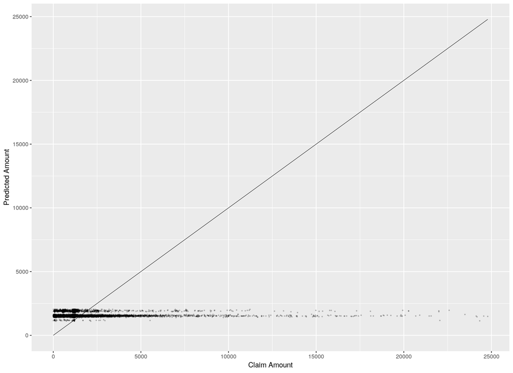

```r
sigma_model4 <- summary(model4)$sigma

ggplot(claimdata_dt) +
    geom_line(aes(x = claim_amount, y = claim_amount), size= 0.25) +
    geom_point(aes(x = claim_amount, y = exp(predict(model4, type = 'response') + 0.5 * sigma_model4^2))
              ,size = 0.4, alpha = 0.2) +
    expand_limits(y = 0) +
    xlab("Claim Amount") +
    ylab("Predicted Amount")
```

We now try using a Gamma distribution:

```r
model5 <- glm(claim_amount ~ power + brand + cat_car_age
             ,family = Gamma(link = 'log')
             ,data = claimdata_dt)

summary(model5)
```

```
##
## Call:
## glm(formula = claim_amount ~ power + brand + cat_car_age, family = Gamma(link = "log"),
##     data = claimdata_dt)
##
## Deviance Residuals:
##     Min       1Q   Median       3Q      Max
## -3.3853  -0.6419  -0.1965  -0.0964   5.4392
##
## Coefficients:
##                                          Estimate Std. Error t value Pr(>|t|)
## (Intercept)                              7.305286   0.056382 129.569  < 2e-16 ***
## powere                                   0.015642   0.035245   0.444  0.65718
## powerf                                   0.016937   0.033580   0.504  0.61401
## powerg                                   0.053441   0.034463   1.551  0.12100
## powerh                                   0.016197   0.048846   0.332  0.74020
## poweri                                   0.052028   0.055085   0.945  0.34493
## powerj                                   0.066362   0.055766   1.190  0.23406
## powerk                                  -0.009322   0.071593  -0.130  0.89640
## powerl                                   0.224744   0.105423   2.132  0.03304 *
## powerm                                   0.035268   0.153579   0.230  0.81837
## powern                                   0.241632   0.173299   1.394  0.16325
## powero                                  -0.050785   0.176396  -0.288  0.77343
## brandJapanese (except Nissan) or Korean  0.050416   0.057355   0.879  0.37941
## brandMercedes, Chrysler or BMW           0.015660   0.067212   0.233  0.81577
## brandOpel, General Motors or Ford       -0.070005   0.057356  -1.221  0.22228
## brandother                              -0.024825   0.079697  -0.311  0.75543
## brandRenault, Nissan or Citroen         -0.040194   0.049983  -0.804  0.42131
## brandVolkswagen, Audi, Skoda or Seat    -0.002665   0.058767  -0.045  0.96383
## cat_car_age(15,Inf]                     -0.106415   0.044329  -2.401  0.01638 *
## cat_car_age(4,15]                       -0.076637   0.026235  -2.921  0.00349 **
## cat_car_age[0,1]                        -0.030839   0.037069  -0.832  0.40546
## ---
## Signif. codes:  0 '***' 0.001 '**' 0.01 '*' 0.05 '.' 0.1 ' ' 1
##
## (Dispersion parameter for Gamma family taken to be 1.629502)
##
##     Null deviance: 14681  on 16067  degrees of freedom
## Residual deviance: 14612  on 16047  degrees of freedom
## AIC: 264956
##
## Number of Fisher Scoring iterations: 7
```

There is standard equivalent of a fixed $R^2$ for GLMs - model fits tend to be relative to other models using AIC and other criterion. I want to plot the outputs against the real values in a similar way.

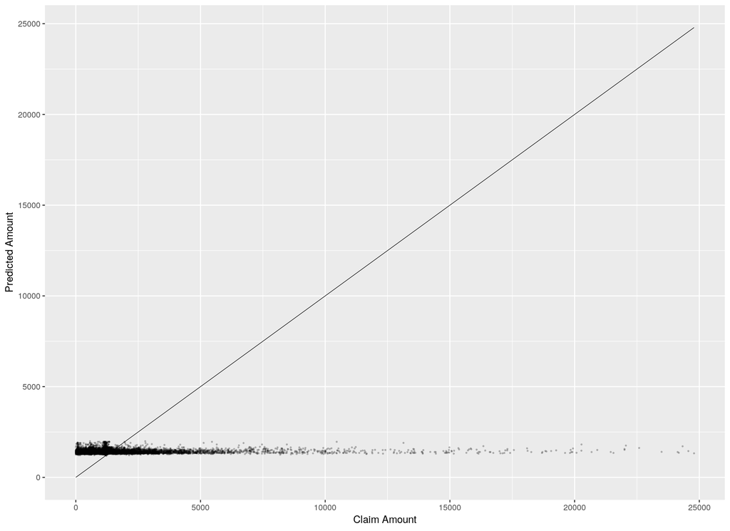

```r
ggplot(claimdata_dt) +
    geom_line(aes(x = claim_amount, y = claim_amount), size = 0.25) +
    geom_point(aes(x = claim_amount, y = predict(model5, type = 'response'))
              ,size = 0.4, alpha = 0.2) +
    expand_limits(y = 0) +
    xlab("Claim Amount") +
    ylab("Predicted Amount")
```

Both models are exceptionally bad.

### 2.2.1 Iterating on Claim Size Prediction

We will try a few more things before we move on.

```r
model6 <- lm(log(claim_amount) ~ brand + cat_car_age + cat_driver_age + fuel +
                                 agg_region
            ,data = claimdata_dt)

summary(model6)
```

```
##
## Call:
## lm(formula = log(claim_amount) ~ brand + cat_car_age + cat_driver_age +
##     fuel + agg_region, data = claimdata_dt)
##
## Residuals:
##     Min      1Q  Median      3Q     Max
## -6.3731 -0.2537  0.2534  0.3722  3.4468
##
## Coefficients:
##                                          Estimate Std. Error t value Pr(>|t|)
## (Intercept)                              6.963350   0.059810 116.425  < 2e-16 ***
## brandJapanese (except Nissan) or Korean  0.218712   0.047013   4.652 3.31e-06 ***
## brandMercedes, Chrysler or BMW          -0.006563   0.054259  -0.121  0.90373
## brandOpel, General Motors or Ford       -0.041093   0.047057  -0.873  0.38253
## brandother                              -0.031059   0.065495  -0.474  0.63535
## brandRenault, Nissan or Citroen         -0.013400   0.041221  -0.325  0.74512
## brandVolkswagen, Audi, Skoda or Seat    -0.006300   0.048356  -0.130  0.89635
## cat_car_age(15,Inf]                      0.008448   0.036744   0.230  0.81815
## cat_car_age(4,15]                       -0.039547   0.021726  -1.820  0.06874 .
## cat_car_age[0,1]                        -0.041015   0.030615  -1.340  0.18036
## cat_driver_age(22,26]                   -0.132883   0.048936  -2.715  0.00663 **
## cat_driver_age(26,42]                   -0.179070   0.038860  -4.608 4.09e-06 ***
## cat_driver_age(42,74]                   -0.109630   0.037988  -2.886  0.00391 **
## cat_driver_age(74,Inf]                   0.078477   0.055213   1.421  0.15523
## fuelRegular                             -0.048655   0.017020  -2.859  0.00426 **
## agg_region                              -0.001544   0.003508  -0.440  0.65986
## ---
## Signif. codes:  0 '***' 0.001 '**' 0.01 '*' 0.05 '.' 0.1 ' ' 1
##
## Residual standard error: 1.055 on 16052 degrees of freedom
## Multiple R-squared:  0.009017,   Adjusted R-squared:  0.008091
## F-statistic: 9.737 on 15 and 16052 DF,  p-value: < 2.2e-16
```

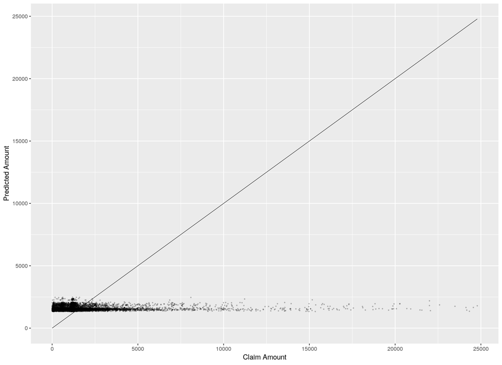

```r
sigma_model6 <- summary(model6)$sigma

ggplot(claimdata_dt) +
    geom_line(aes(x = claim_amount, y = claim_amount), size = 0.25) +
    geom_point(aes(x = claim_amount, y = exp(predict(model6, type = 'response') + 0.5 * sigma_model6^2))
              ,size = 0.4, alpha = 0.2) +
    expand_limits(y = 0) +
    xlab("Claim Amount") +
    ylab("Predicted Amount")
```

Again we have a similar problem - the model is terrible. Alarmingly, it focuses all the claims at a small part of the observed claims distribution and so is very bad for prediction. We need better.

```r
model7 <- glm(claim_amount ~ brand + cat_car_age + cat_driver_age +
                             fuel + agg_region
             ,family = Gamma(link = 'log')
             ,data = claimdata_dt)

summary(model7)
```

```
##
## Call:
## glm(formula = claim_amount ~ brand + cat_car_age + cat_driver_age +
##     fuel + agg_region, family = Gamma(link = "log"), data = claimdata_dt)
##
## Deviance Residuals:
##     Min       1Q   Median       3Q      Max
## -3.3819  -0.6331  -0.1987  -0.0852   5.4437
##
## Coefficients:
##                                           Estimate Std. Error t value Pr(>|t|)
## (Intercept)                              7.553e+00  7.207e-02 104.797  < 2e-16 ***
## brandJapanese (except Nissan) or Korean  6.924e-02  5.665e-02   1.222  0.22163
## brandMercedes, Chrysler or BMW           3.672e-02  6.538e-02   0.562  0.57435
## brandOpel, General Motors or Ford       -6.938e-02  5.671e-02  -1.223  0.22118
## brandother                              -5.264e-03  7.892e-02  -0.067  0.94682
## brandRenault, Nissan or Citroen         -4.995e-02  4.967e-02  -1.006  0.31467
## brandVolkswagen, Audi, Skoda or Seat    -1.234e-02  5.827e-02  -0.212  0.83227
## cat_car_age(15,Inf]                     -1.069e-01  4.428e-02  -2.414  0.01580 *
## cat_car_age(4,15]                       -7.761e-02  2.618e-02  -2.964  0.00304 **
## cat_car_age[0,1]                        -3.880e-02  3.689e-02  -1.052  0.29297
## cat_driver_age(22,26]                   -1.897e-01  5.897e-02  -3.217  0.00130 **
## cat_driver_age(26,42]                   -2.365e-01  4.683e-02  -5.050 4.47e-07 ***
## cat_driver_age(42,74]                   -2.119e-01  4.578e-02  -4.630 3.69e-06 ***
## cat_driver_age(74,Inf]                  -8.254e-02  6.653e-02  -1.241  0.21477
## fuelRegular                             -3.216e-02  2.051e-02  -1.568  0.11683
## agg_region                               1.778e-05  4.227e-03   0.004  0.99665
## ---
## Signif. codes:  0 '***' 0.001 '**' 0.01 '*' 0.05 '.' 0.1 ' ' 1
##
## (Dispersion parameter for Gamma family taken to be 1.617328)
##
##     Null deviance: 14681  on 16067  degrees of freedom
## Residual deviance: 14573  on 16052  degrees of freedom
## AIC: 264898
##
## Number of Fisher Scoring iterations: 6
```

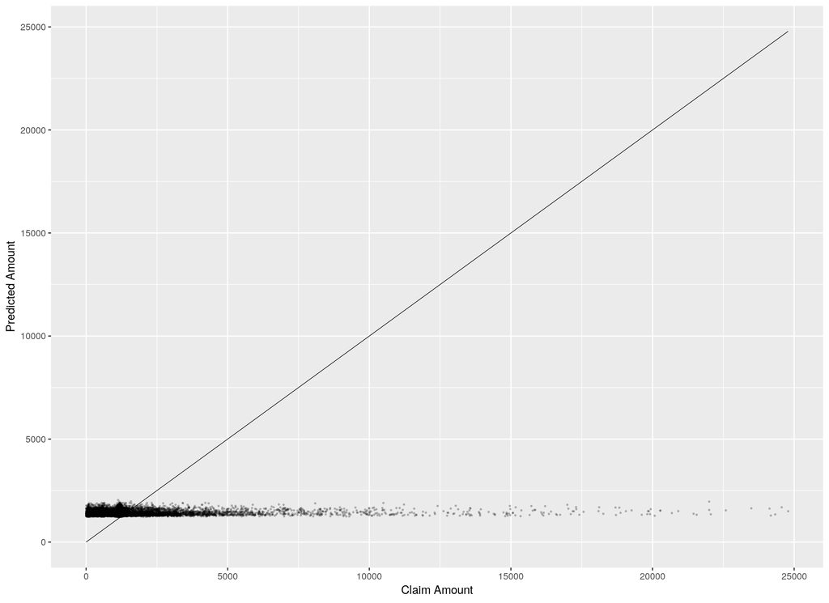

```r
ggplot(claimdata_dt) +
    geom_line(aes(x = claim_amount, y = claim_amount), size = 0.25) +
    geom_point(aes(x = claim_amount, y = predict(model7, type = 'response'))
              ,size = 0.4, alpha = 0.2) +
    expand_limits(y = 0) +
    xlab("Claim Amount") +
    ylab("Predicted Amount")
```

# 3 Model Assessment

We have not done a hugely rigourous assessment of the Poisson regression for claims rate, and we already know that the claim size regression is terrible so we need to get a much better model for claim size and should figure out how well our Poisson GLM does at capturing the claim rate.

We will start with the claim size as our initial models were so poor. We need to experiment.

The main concern is how the regression output provided low estimates for the claim amount. This is an issue that needs to be addressed first.

One idea might be to reduce the size of the claims that we model in this way - by lowering the value of ‘expected’ claims it may be easier to model them. This means our method for estimating larger claims needs to handle this, but we can deal with that later.

To try this, we should look at a plot of the current distribution.

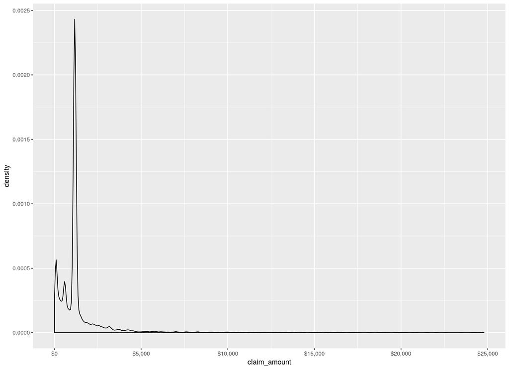

```r
ggplot(claimdata_dt) +
    geom_density(aes(x = claim_amount)) +
    scale_x_continuous(labels = scales::dollar)
```

The tail is long, and as our power law distribution seems to work for claims from about EUR 1,000, we may wish to truncate the claims data further. Let us parse it down to EUR 5,000 and try again.

```r
claim_5000_dt <- claimdata_dt %>%
    filter(claim_amount < 5000)
```

```r
model8 <- lm(log(claim_amount) ~ power + brand + cat_car_age
            ,data = claim_5000_dt)

summary(model8)
```

```
##
## Call:
## lm(formula = log(claim_amount) ~ power + brand + cat_car_age,
##     data = claim_5000_dt)
##
## Residuals:
##     Min      1Q  Median      3Q     Max
## -6.2531 -0.2379  0.3281  0.4101  1.8568
##
## Coefficients:
##                                          Estimate Std. Error t value Pr(>|t|)
## (Intercept)                              6.684784   0.044301 150.895  < 2e-16 ***
## powere                                   0.022824   0.027642   0.826   0.4090
## powerf                                   0.023956   0.026320   0.910   0.3627
## powerg                                   0.001902   0.027064   0.070   0.9440
## powerh                                   0.039372   0.038360   1.026   0.3047
## poweri                                   0.044520   0.043299   1.028   0.3039
## powerj                                   0.046581   0.043887   1.061   0.2885
## powerk                                  -0.045964   0.056270  -0.817   0.4140
## powerl                                  -0.069055   0.084730  -0.815   0.4151
## powerm                                   0.018378   0.121188   0.152   0.8795
## powern                                  -0.289310   0.136231  -2.124   0.0337 *
## powero                                  -0.301780   0.140029  -2.155   0.0312 *
## brandJapanese (except Nissan) or Korean  0.214894   0.045136   4.761 1.94e-06 ***
## brandMercedes, Chrysler or BMW           0.003082   0.052918   0.058   0.9536
## brandOpel, General Motors or Ford       -0.015508   0.044973  -0.345   0.7302
## brandother                              -0.026108   0.062603  -0.417   0.6766
## brandRenault, Nissan or Citroen          0.012558   0.039218   0.320   0.7488
## brandVolkswagen, Audi, Skoda or Seat     0.012518   0.046112   0.271   0.7860
## cat_car_age(15,Inf]                      0.035979   0.034762   1.035   0.3007
## cat_car_age(4,15]                       -0.017215   0.020664  -0.833   0.4048
## cat_car_age[0,1]                        -0.035317   0.029283  -1.206   0.2278
## ---
## Signif. codes:  0 '***' 0.001 '**' 0.01 '*' 0.05 '.' 0.1 ' ' 1
##
## Residual standard error: 0.9853 on 15503 degrees of freedom
## Multiple R-squared:  0.005774,   Adjusted R-squared:  0.004492
## F-statistic: 4.502 on 20 and 15503 DF,  p-value: 7.933e-11
```

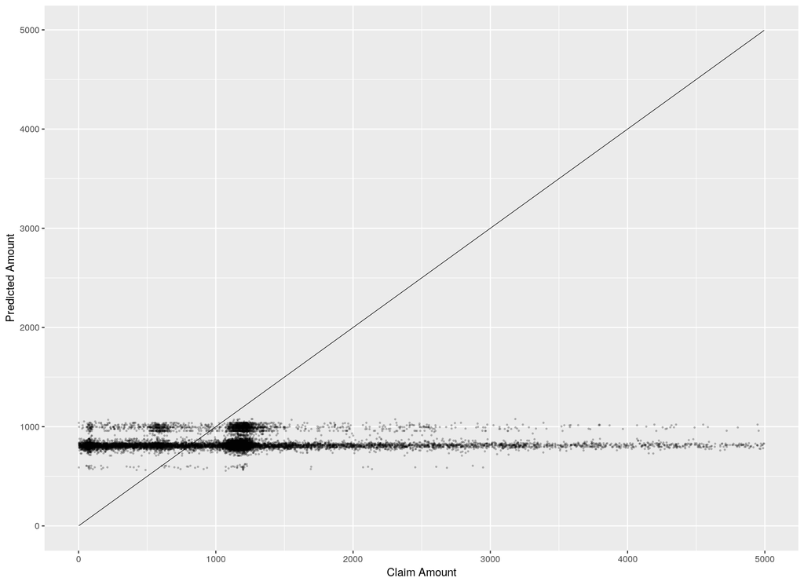

```r
ggplot(claim_5000_dt) +
    geom_line(aes(x = claim_amount, y = claim_amount), size = 0.25) +
    geom_point(aes(x = claim_amount, y = exp(predict(model8, type = 'response')))
              ,size = 0.4, alpha = 0.2) +
    expand_limits(y = 0) +
    xlab("Claim Amount") +
    ylab("Predicted Amount")
```

We now try using a Gamma distribution:

```r
model9 <- glm(claim_amount ~ power + brand + cat_car_age
             ,family = Gamma(link = 'log')
             ,data = claim_5000_dt)

summary(model9)
```

```
##
## Call:
## glm(formula = claim_amount ~ power + brand + cat_car_age, family = Gamma(link = "log"),
##     data = claim_5000_dt)
##
## Deviance Residuals:
##     Min       1Q   Median       3Q      Max
## -3.2960  -0.5166   0.0035   0.0786   1.9853
##
## Coefficients:
##                                         Estimate Std. Error t value Pr(>|t|)
## (Intercept)                              7.00302    0.03120 224.462   <2e-16 ***
## powere                                   0.03318    0.01947   1.704   0.0883 .
## powerf                                   0.04005    0.01854   2.161   0.0307 *
## powerg                                   0.01954    0.01906   1.025   0.3053
## powerh                                   0.02732    0.02702   1.011   0.3118
## poweri                                   0.05407    0.03049   1.773   0.0762 .
## powerj                                   0.05028    0.03091   1.627   0.1038
## powerk                                  -0.01686    0.03963  -0.425   0.6705
## powerl                                  -0.03133    0.05967  -0.525   0.5995
## powerm                                   0.10228    0.08535   1.198   0.2308
## powern                                  -0.15317    0.09594  -1.596   0.1104
## powero                                  -0.14541    0.09862  -1.475   0.1404
## brandJapanese (except Nissan) or Korean  0.07013    0.03179   2.206   0.0274 *
## brandMercedes, Chrysler or BMW           0.05890    0.03727   1.580   0.1140
## brandOpel, General Motors or Ford        0.02868    0.03167   0.905   0.3652
## brandother                               0.03442    0.04409   0.781   0.4349
## brandRenault, Nissan or Citroen          0.03363    0.02762   1.218   0.2233
## brandVolkswagen, Audi, Skoda or Seat     0.05806    0.03247   1.788   0.0738 .
## cat_car_age(15,Inf]                     -0.03422    0.02448  -1.398   0.1622
## cat_car_age(4,15]                       -0.03350    0.01455  -2.302   0.0214 *
## cat_car_age[0,1]                        -0.03843    0.02062  -1.864   0.0624 .
## ---
## Signif. codes:  0 '***' 0.001 '**' 0.01 '*' 0.05 '.' 0.1 ' ' 1
##
## (Dispersion parameter for Gamma family taken to be 0.4814851)
##
##     Null deviance: 10004  on 15523  degrees of freedom
## Residual deviance:  9989  on 15503  degrees of freedom
## AIC: 247531
##
## Number of Fisher Scoring iterations: 5
```

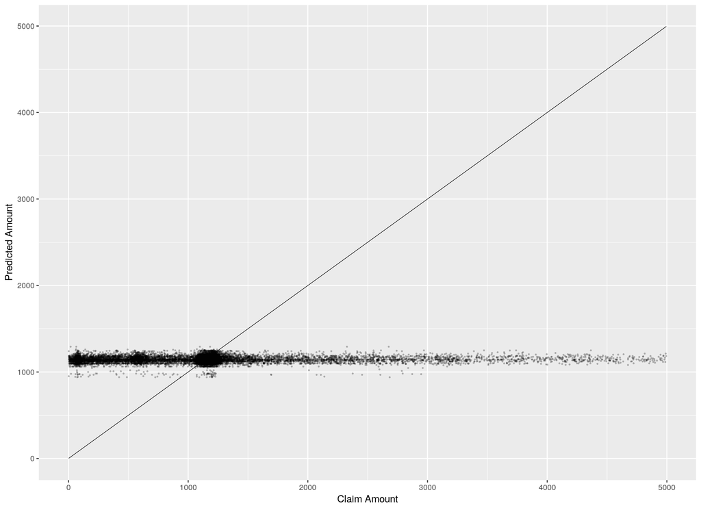

```r
ggplot(claim_5000_dt) +
    geom_line (aes(x = claim_amount, y = claim_amount), size = 0.25) +
    geom_point(aes(x = claim_amount, y = predict(model9, type = 'response'))
              ,size = 0.4, alpha = 0.2) +
    expand_limits(y = 0) +
    xlab("Claim Amount") +
    ylab("Predicted Amount")
```

We still get a narrow range of predictions. We need to change our approach.

## 3.1 Regression from Computational Actuarial Science Textbook

While unlikely to be much better, it is worth trying the regressions ran in the textbook. We have low expectations for quality but it is worth checking.

We first look at the lognormal regression.

```r
claim_15000_dt <- claimdata_dt %>%
    filter(claim_amount < 15000)

model10 <- lm(log(claim_amount) ~ cat_car_age + fuel, data = claim_15000_dt)

summary(model10)
```

```
##
## Call:
## lm(formula = log(claim_amount) ~ cat_car_age + fuel, data = claim_15000_dt)
##
## Residuals:
##     Min      1Q  Median      3Q     Max
## -6.1546 -0.2581  0.2631  0.3514  2.8667
##
## Coefficients:
##                       Estimate Std. Error t value Pr(>|t|)
## (Intercept)          6.8477884  0.0194580 351.926  < 2e-16 ***
## cat_car_age(15,Inf] -0.0357952  0.0357133  -1.002 0.316218
## cat_car_age(4,15]   -0.0807691  0.0208897  -3.866 0.000111 ***
## cat_car_age[0,1]     0.0006807  0.0299139   0.023 0.981845
## fuelRegular         -0.0224963  0.0166126  -1.354 0.175699
## ---
## Signif. codes:  0 '***' 0.001 '**' 0.01 '*' 0.05 '.' 0.1 ' ' 1
##
## Residual standard error: 1.044 on 16001 degrees of freedom
## Multiple R-squared:  0.001438,   Adjusted R-squared:  0.001189
## F-statistic: 5.762 on 4 and 16001 DF,  p-value: 0.0001247
```

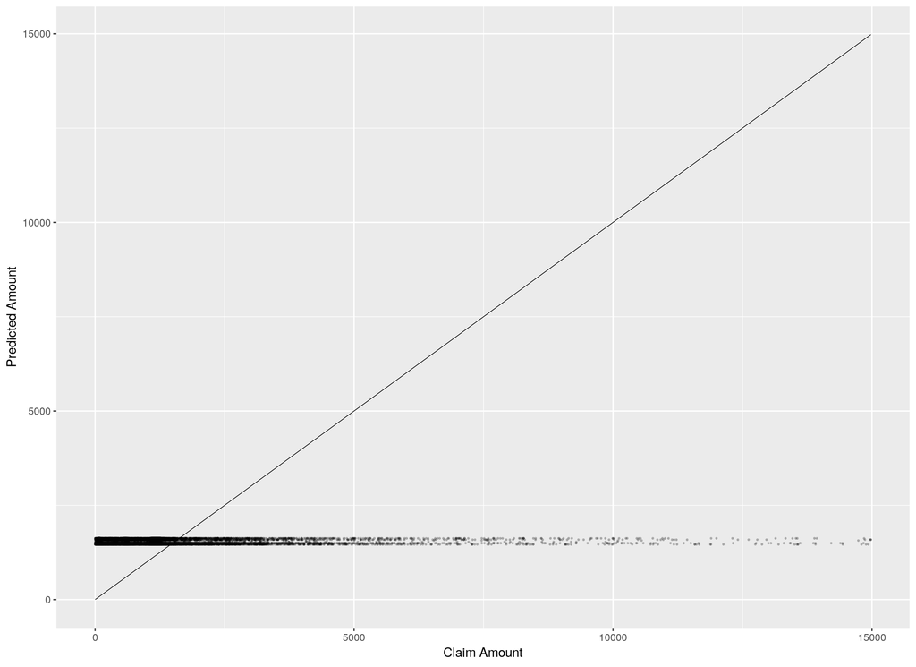

```r
sigma_model10 <- summary(model10)$sigma

ggplot(claim_15000_dt) +
    geom_line(aes(x = claim_amount, y = claim_amount), size = 0.25) +
    geom_point(aes(x = claim_amount, y = exp(predict(model10, type = 'response') + 0.5 * sigma_model10^2))
              ,size = 0.4, alpha = 0.2) +
    expand_limits(y = 0) +
    xlab("Claim Amount") +
    ylab("Predicted Amount")
```

And we look at the Gamma regression.

```r
model11 <- glm(claim_amount ~ cat_car_age + fuel
              ,family = Gamma(link = 'log')
              ,data = claim_15000_dt)

summary(model11)
```

```
##
## Call:
## glm(formula = claim_amount ~ cat_car_age + fuel, family = Gamma(link = "log"),
##     data = claim_15000_dt)
##
## Deviance Residuals:
##     Min       1Q   Median       3Q      Max
## -3.3437  -0.6102  -0.1516  -0.0640   4.0165
##
## Coefficients:
##                     Estimate Std. Error t value Pr(>|t|)
## (Intercept)          7.28180    0.02025 359.663  < 2e-16 ***
## cat_car_age(15,Inf] -0.10877    0.03716  -2.927  0.00343 **
## cat_car_age(4,15]   -0.09505    0.02174  -4.373 1.23e-05 ***
## cat_car_age[0,1]    -0.02196    0.03113  -0.706  0.48040
## fuelRegular         -0.01873    0.01729  -1.083  0.27864
## ---
## Signif. codes:  0 '***' 0.001 '**' 0.01 '*' 0.05 '.' 0.1 ' ' 1
##
## (Dispersion parameter for Gamma family taken to be 1.180372)
##
##     Null deviance: 13455  on 16005  degrees of freedom
## Residual deviance: 13423  on 16001  degrees of freedom
## AIC: 262054
##
## Number of Fisher Scoring iterations: 5
```

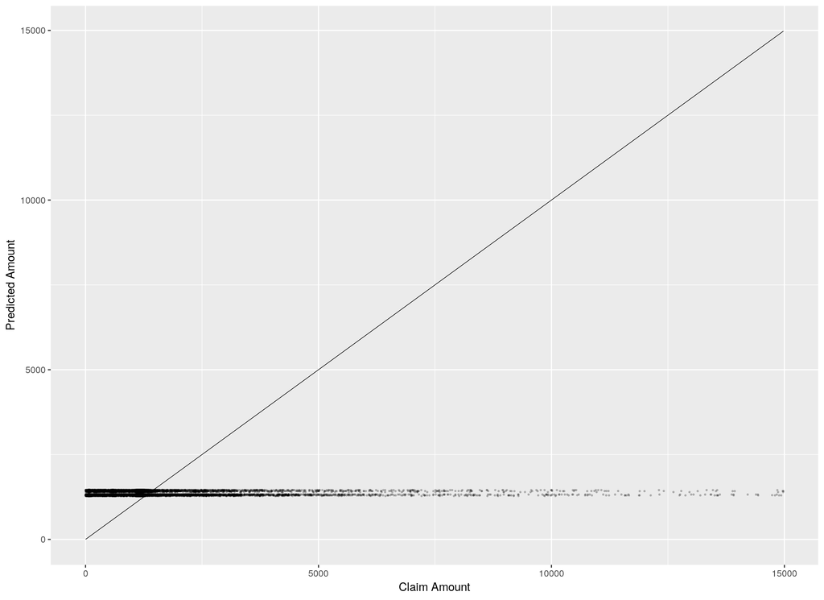

```r
ggplot(claim_15000_dt) +
    geom_line(aes(x = claim_amount, y = claim_amount), size = 0.25) +
    geom_point(aes(x = claim_amount, y = predict(model11, type = 'response'))
              ,size = 0.4, alpha = 0.2) +
    expand_limits(y = 0) +
    xlab("Claim Amount") +
    ylab("Predicted Amount")
```

## 3.2 Estimating Claim Distributions

Instead of trying to create a predictive model for the claims, we instead try to fit a distribution, partitioning the data by a few different categorical variables. Rather than predict a claim, we will randomly draw from the distribution. We can check this first.

We first partition on `car_age` and look at the distribution of the log of the claim amount.

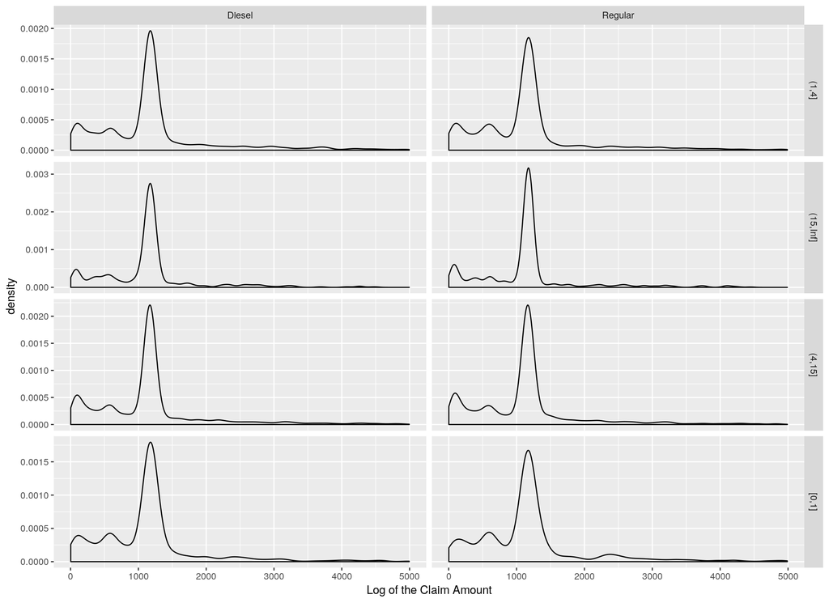

```r
ggplot(claim_5000_dt) +
    geom_density(aes(x = claim_amount)) +
    facet_grid(cat_car_age ~ fuel, scales = 'free') +
    xlab("Log of the Claim Amount")
```

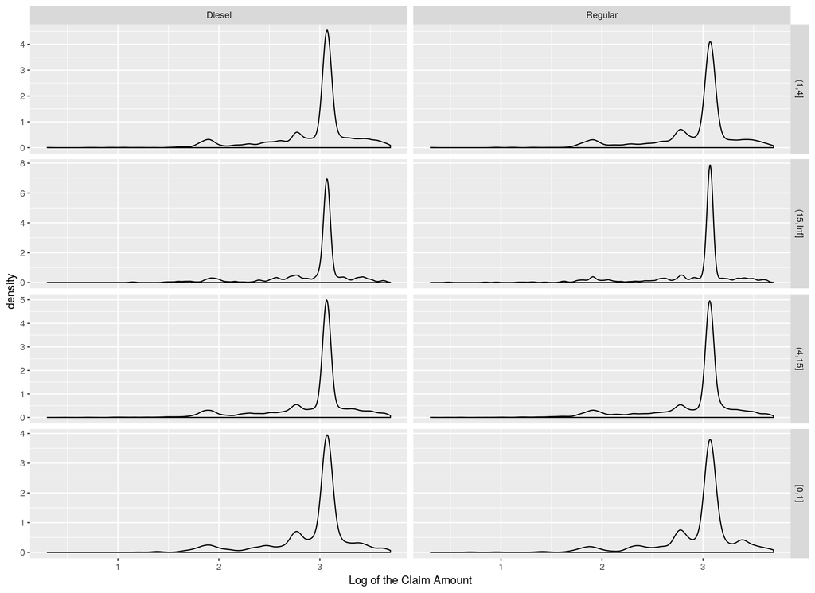

```r
ggplot(claim_5000_dt) +
    geom_density(aes(x = log10(claim_amount))) +
    facet_grid(cat_car_age ~ fuel, scales = 'free') +
    xlab("Log of the Claim Amount")
```

## 3.3 Feature Selection using Boruta

As one final attempt, we will try Boruta on the dataset. Boruta uses random forests against all the columns in the table and checks for predictive power.

```r
claimdata_boruta_dt <- claimdata_dt %>%
    select(-c(policy_id,exposure,total_claims))

claimdata_boruta <- Boruta(claim_amount ~ .
                          ,data = claimdata_boruta_dt
                          ,doTrace = 2, ntree = 100)

print(claimdata_boruta$finalDecision)
```

```
##          power        car_age     driver_age          brand           fuel         region
##       Rejected      Confirmed      Confirmed      Confirmed      Confirmed      Confirmed
##        density cat_driver_age    cat_car_age    cat_density      agg_power    agg_power_2
##      Confirmed      Confirmed      Confirmed      Confirmed       Rejected       Rejected
##     agg_region
##      Confirmed
## Levels: Tentative Confirmed Rejected
```

We will try fitting one last Gamma distribution using the features from Boruta: `car_age`, `driver_age`, `brand`, `fuel`, `region`, `density`.

```r
model12 <- glm(claim_amount ~ car_age + driver_age + brand + fuel + region +
                              density
              ,family = Gamma(link = 'log')
              ,data = claim_5000_dt)

summary(model12)
```

```
##
## Call:
## glm(formula = claim_amount ~ car_age + driver_age + brand + fuel +
##     region + density, family = Gamma(link = "log"), data = claim_5000_dt)
##
## Deviance Residuals:
##     Min       1Q   Median       3Q      Max
## -3.2793  -0.5145   0.0024   0.0821   2.0139
##
## Coefficients:
##                                           Estimate Std. Error t value Pr(>|t|)
## (Intercept)                              7.046e+00  3.894e-02 180.939   <2e-16 ***
## car_age                                 -2.211e-03  1.150e-03  -1.923   0.0545 .
## driver_age                               5.093e-04  3.794e-04   1.342   0.1795
## brandJapanese (except Nissan) or Korean  5.127e-02  3.165e-02   1.620   0.1052
## brandMercedes, Chrysler or BMW           5.522e-02  3.633e-02   1.520   0.1286
## brandOpel, General Motors or Ford        2.858e-02  3.144e-02   0.909   0.3632
## brandother                               3.440e-02  4.387e-02   0.784   0.4329
## brandRenault, Nissan or Citroen          3.409e-02  2.758e-02   1.236   0.2164
## brandVolkswagen, Audi, Skoda or Seat     5.731e-02  3.232e-02   1.773   0.0762 .
## fuelRegular                             -1.568e-02  1.147e-02  -1.367   0.1715
## regionBasse-Normandie                   -4.929e-02  3.991e-02  -1.235   0.2168
## regionBretagne                          -1.213e-02  2.752e-02  -0.441   0.6594
## regionCentre                            -4.891e-02  2.392e-02  -2.045   0.0409 *
## regionHaute-Normandie                    1.647e-02  5.229e-02   0.315   0.7528
## regionIle-de-France                     -6.216e-03  2.829e-02  -0.220   0.8261
## regionLimousin                          -9.529e-02  5.484e-02  -1.738   0.0823 .
## regionNord-Pas-de-Calais                -2.727e-02  3.202e-02  -0.852   0.3944
## regionPays-de-la-Loire                  -6.074e-02  2.835e-02  -2.142   0.0322 *
## regionPoitou-Charentes                  -2.747e-02  3.336e-02  -0.823   0.4104
## density                                 -3.339e-06  1.405e-06  -2.376   0.0175 *
## ---
## Signif. codes:  0 '***' 0.001 '**' 0.01 '*' 0.05 '.' 0.1 ' ' 1
##
## (Dispersion parameter for Gamma family taken to be 0.4815117)
##
##     Null deviance: 10004.0  on 15523  degrees of freedom
## Residual deviance:  9987.1  on 15504  degrees of freedom
## AIC: 247525
##
## Number of Fisher Scoring iterations: 5
```

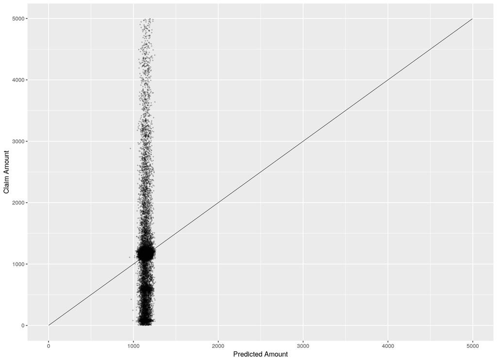

```r
ggplot(claim_5000_dt) +
    geom_line (aes(x = claim_amount, y = claim_amount), size = 0.25) +
    geom_point(aes(x = predict(model12, type = 'response'), y = claim_amount)
              ,size = 0.4, alpha = 0.2) +
    expand_limits(y = 0) +
    xlab("Predicted Amount") +
    ylab("Claim Amount")
```

Once again, the model is quite a poor fit with a lot of unexplained variance.